# Overview of Crop Yield and Economic Impacts in USA

Shila Pokhrel

Nov 26, 2024

#Project Summary:

This report begin with presenting the overall overview of the total crop yield per hector and the economic impact across different countries.In detail, the United States data has been tested across different crop types and over time. This report presents some statistical analysis including frequency analysis, trend analysis, linear regression model, and correlation tests.

##Data Variable:

Year: Year of data collection.

Country: Country name.

Region: Regional designation within the country.

Crop_Type: Type of crop.

Average_Temperature_C: Average temperature in Celsius.

Total_Precipitation_mm: Total precipitation in millimeters.

CO2_Emissions_MT: Carbon dioxide emissions in metric tons.

Crop_Yield_MT_per_HA: Crop yield in metric tons per hectare.

Extreme_Weather_Events: Number of extreme weather events.

Irrigation_Access_%: Percentage access to irrigation.

Pesticide_Use_KG_per_HA: Pesticide usage in kilograms per hectare.

Fertilizer_Use_KG_per_HA: Fertilizer usage in kilograms per hectare.

Soil_Health_Index: Index measuring soil health.

Adaptation_Strategies: Types of adaptation strategies used.

Economic_Impact_Million_USD: Economic impact in million USD.

##Summary of the Data

```
##       Year        Country             Region           Crop_Type
##  Min.   :1990   Length:10000       Length:10000       Length:10000
##  1st Qu.:1999   Class :character   Class :character   Class :character
##  Median :2007   Mode  :character   Mode  :character   Mode  :character
##  Mean   :2007
##  3rd Qu.:2016
##  Max.   :2024
##  Average_Temperature_C Total_Precipitation_mm CO2_Emissions_MT
##  Min.   :-4.99         Min.   : 200.2         Min.   : 0.50
##  1st Qu.: 5.43         1st Qu.: 925.7         1st Qu.: 7.76
##  Median :15.18         Median :1611.2         Median :15.20
##  Mean   :15.24         Mean   :1611.7         Mean   :15.25
##  3rd Qu.:25.34         3rd Qu.:2307.0         3rd Qu.:22.82
##  Max.   :35.00         Max.   :2999.7         Max.   :30.00
##  Crop_Yield_MT_per_HA Extreme_Weather_Events Irrigation_Access_.
##  Min.   :0.450        Min.   : 0.000         Min.   :10.01
##  1st Qu.:1.449        1st Qu.: 2.000         1st Qu.:32.68
##  Median :2.170        Median : 5.000         Median :55.17
##  Mean   :2.240        Mean   : 4.981         Mean   :55.25
##  3rd Qu.:2.930        3rd Qu.: 8.000         3rd Qu.:77.58
##  Max.   :5.000        Max.   :10.000         Max.   :99.99
##  Pesticide_Use_KG_per_HA Fertilizer_Use_KG_per_HA Soil_Health_Index
##  Min.   : 0.00           Min.   : 0.01            Min.   : 30.00
##  1st Qu.:12.53           1st Qu.:25.39            1st Qu.: 47.23
##  Median :24.93           Median :49.63            Median : 64.65
##  Mean   :24.96           Mean   :49.97            Mean   : 64.90
##  3rd Qu.:37.47           3rd Qu.:74.83            3rd Qu.: 82.47
##  Max.   :49.99           Max.   :99.99            Max.   :100.00
##  Adaptation_Strategies Economic_Impact_Million_USD
##  Length:10000          Min.   :  47.84
##  Class :character      1st Qu.: 350.55
##  Mode  :character      Median : 583.92
##                        Mean   : 674.27
##                        3rd Qu.: 917.50
##                        Max.   :2346.47
```

## Overall summary of data: Total Crop yield in MT per HA and Economic Impact in USD by Countries

-Brazil has the least crop production among countries with total crop production of 2106.48MT per Ha and economic impact of $637327.8 million.

Summary of Crop Yield and Economic Impact by Country

| Country | Total_Crop_Yield_MT_per_HA | Mean_Crop_Yield_MT_Per_HA | Total_Economic_Impact |
| --- | --- | --- | --- |
| Nigeria | 2345.53 | 2.28 | 719560.3 |
| India | 2305.80 | 2.25 | 700498.0 |
| China | 2330.28 | 2.26 | 695605.2 |
| USA | 2309.78 | 2.24 | 686338.9 |
| Australia | 2304.03 | 2.23 | 682067.1 |
| Canada | 2193.66 | 2.23 | 669240.0 |
| Argentina | 2214.34 | 2.25 | 663271.0 |
| France | 2172.55 | 2.22 | 648634.5 |
| Russia | 2117.72 | 2.20 | 640153.7 |
| Brazil | 2106.48 | 2.23 | 637327.8 |

-Barley and Coffee: USA

-Brazil and Canada: wheat

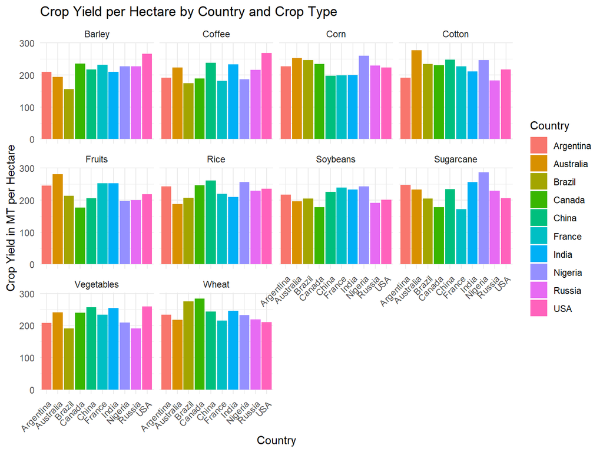

## Testing significance of difference in crop yield in MT per HA across different countries

There is no significant differences in Crop yield production among the tested countries.

```
##               Df Sum Sq Mean Sq F value Pr(>F)
## Country        9      4  0.4519   0.453  0.906
## Residuals   9990   9962  0.9972
```

#Total Economic Impact in Million USD by country and crop type

-The trend is quite similar to crop yield.

-There is no statistically significant differences in economic impact among the different countries.

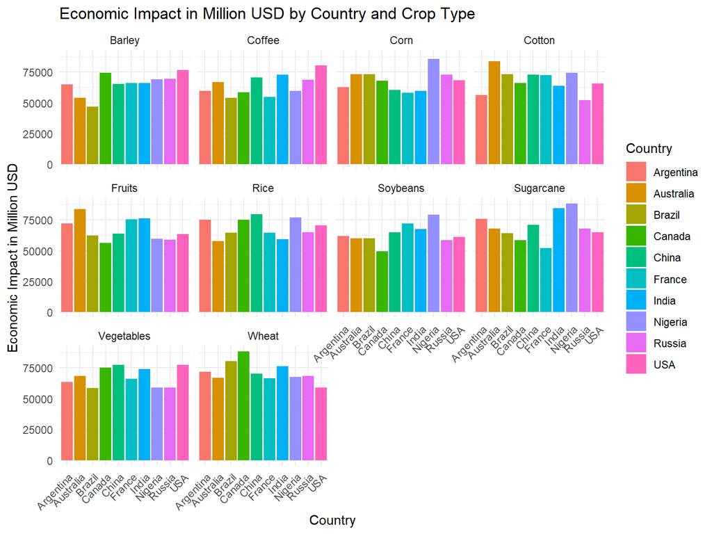

##Testing significance of difference in economic impact among the different countries

```
##               Df    Sum Sq Mean Sq F value Pr(>F)
## Country        9 1.219e+06  135391   0.788  0.628
## Residuals   9990 1.717e+09  171919
```

# Crop yield and economic impact by crop types in USA

-Coffee and vegetables have highest economic impacts in USA

_Wheat has the least impact

Crop yield and Economic Impact in USA by Crop type

| Crop_Type | Total_Crop_Yield_MT_Per_HA | Avg_Crop_Yield_MT_Per_HA | Total_Economic_Impact |
| --- | --- | --- | --- |
| Coffee | 269.013 | 2.279771 | 80195.23 |
| Vegetables | 259.467 | 2.198873 | 77439.25 |
| Barley | 266.418 | 2.357681 | 76437.73 |
| Rice | 235.915 | 2.204813 | 70434.56 |
| Corn | 223.321 | 2.350747 | 68198.04 |
| Cotton | 217.702 | 2.155465 | 65595.38 |
| Sugarcane | 206.586 | 2.086727 | 64785.89 |
| Fruits | 218.906 | 2.233735 | 63227.20 |
| Soybeans | 201.982 | 2.376259 | 61143.65 |
| Wheat | 210.468 | 2.147633 | 58881.97 |

##Crop yield vs average temperature in USA

-Most crops perform better within a temperature range of 15°C to 25°C, with yields declining or plateauing at higher temperatures.

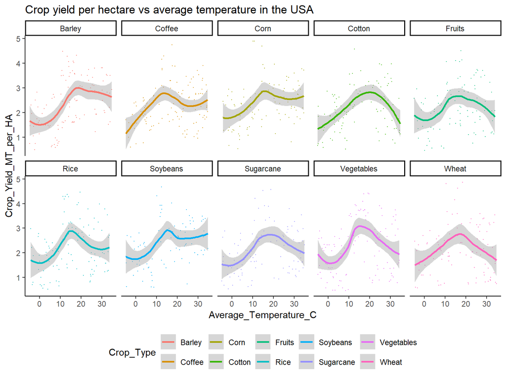

#Correlation between different variables

-There is strong positive correlation between crop yield per HA and the economic impacts

-There is positive correlation of crop yield and economic impacts with average temperature

_There is negative correlation of crop yield and economic impacts with CO2 emissions.

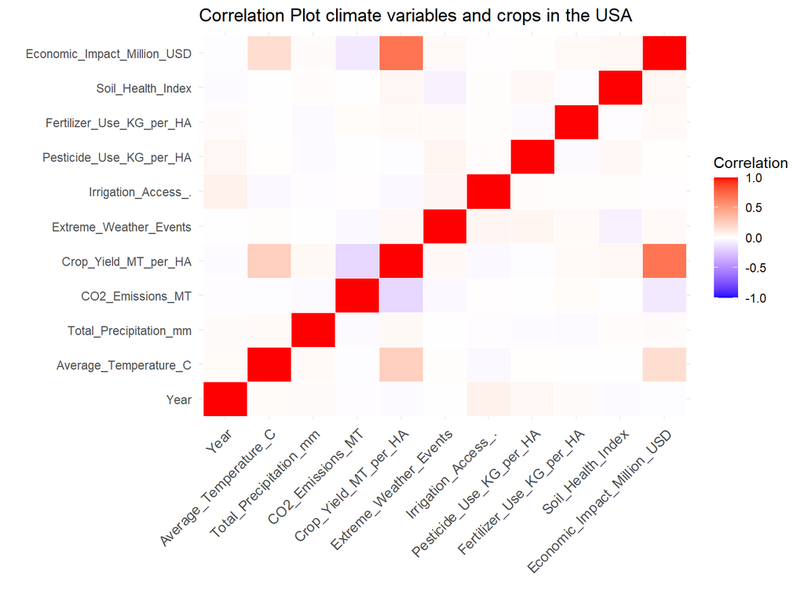

#Trend Analysis of Crop yield in USA over time

-Barley, Corn, Cotton, and Wheat: These crops show relatively stable trends with some fluctuations.

-Coffee and Fruits: These show more pronounced variability over time.

-Rice and Sugarcane: These crops exhibit periodic fluctuations but remain within a consistent range.

-Vegetables: This category shows irregular and sharp changes in yield over time.

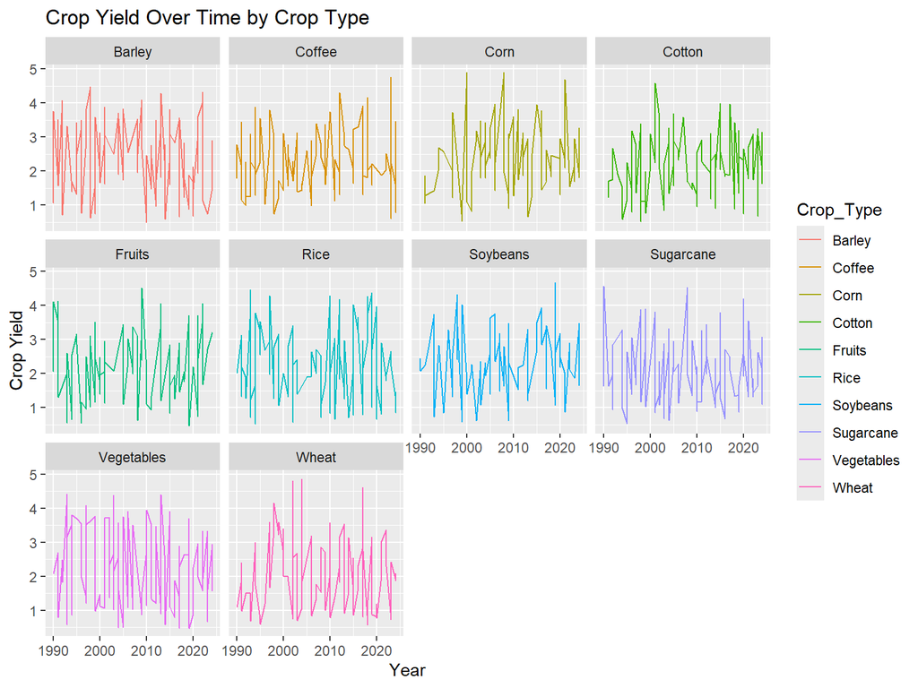

##Statistical test of difference in crop yield over the time

These is no significant differences in crop yield in USA over time.

```
##  [1] "Barley"     "Coffee"     "Corn"       "Cotton"     "Fruits"
##  [6] "Rice"       "Soybeans"   "Sugarcane"  "Vegetables" "Wheat"
```

```
##               Df Sum Sq Mean Sq F value Pr(>F)
## Year           1    0.2  0.2369   0.256  0.613
## Residuals   1030  952.8  0.9251
```

#Trend analysis of economic impact in million USD by crop types over time

-Most crops shows no clear increasing or decreasing trend in ther economic impact over the years.

For example; -Barley displays moderate fluctuations over time, with peak occasionally exceeding $1500 million.

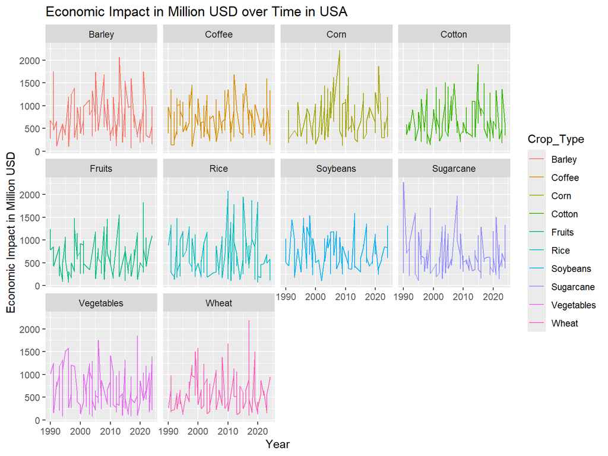

##Statistical test of differences in economic impact over the years

-There is no significant differences in economic impact across the time.

```
##  [1] "Barley"     "Coffee"     "Corn"       "Cotton"     "Fruits"
##  [6] "Rice"       "Soybeans"   "Sugarcane"  "Vegetables" "Wheat"
```

```
##               Df    Sum Sq Mean Sq F value Pr(>F)
## Year           1     30891   30891   0.192  0.661
## Residuals   1030 165547869  160726
```

#Multiple Linear Regression Model

_To understand the influences of multiple factors in crop yield and economic impact

-Only the average temperature and Co2 emissions are found to have significant influence in crop yield and economic impact.

-The very low value of adjusted R2 indicates the poor performance of the linear model

```
##
## Call:
## lm(formula = FM$Crop_Yield_MT_per_HA ~ FM$Average_Temperature_C +
##     FM$Total_Precipitation_mm + FM$CO2_Emissions_MT + FM$Extreme_Weather_Events +
##     FM$Irrigation_Access_. + FM$Pesticide_Use_KG_per_HA + FM$Soil_Health_Index)
##
## Residuals:
##      Min       1Q   Median       3Q      Max
## -1.87954 -0.69335 -0.02808  0.62174  2.63591
##
## Coefficients:
##                              Estimate Std. Error t value Pr(>|t|)
## (Intercept)                 2.046e+00  1.567e-01  13.058  < 2e-16 ***
## FM$Average_Temperature_C    2.037e-02  2.467e-03   8.254 4.68e-16 ***
## FM$Total_Precipitation_mm   2.571e-05  3.613e-05   0.712    0.477
## FM$CO2_Emissions_MT        -1.812e-02  3.247e-03  -5.580 3.08e-08 ***
## FM$Extreme_Weather_Events   9.567e-03  8.992e-03   1.064    0.288
## FM$Irrigation_Access_.     -8.563e-04  1.113e-03  -0.769    0.442
## FM$Pesticide_Use_KG_per_HA -1.201e-03  1.974e-03  -0.608    0.543
## FM$Soil_Health_Index        2.129e-03  1.423e-03   1.496    0.135
## ---
## Signif. codes:  0 '***' 0.001 '**' 0.01 '*' 0.05 '.' 0.1 ' ' 1
##
## Residual standard error: 0.9181 on 1024 degrees of freedom
## Multiple R-squared:  0.09432,    Adjusted R-squared:  0.08813
## F-statistic: 15.23 on 7 and 1024 DF,  p-value: < 2.2e-16
```

```
##
## Call:
## lm(formula = FM$Economic_Impact_Million_USD ~ FM$Average_Temperature_C +
##     FM$Total_Precipitation_mm + FM$CO2_Emissions_MT + FM$Extreme_Weather_Events +
##     FM$Irrigation_Access_. + FM$Pesticide_Use_KG_per_HA + FM$Soil_Health_Index)
##
## Residuals:
##     Min      1Q  Median      3Q     Max
## -701.60 -298.15  -95.62  244.29 1599.00
##
## Coefficients:
##                              Estimate Std. Error t value Pr(>|t|)
## (Intercept)                536.716343  67.176920   7.990 3.63e-15 ***
## FM$Average_Temperature_C     6.000456   1.057960   5.672 1.84e-08 ***
## FM$Total_Precipitation_mm    0.005854   0.015493   0.378  0.70563
## FM$CO2_Emissions_MT         -4.019749   1.392186  -2.887  0.00397 **
## FM$Extreme_Weather_Events    3.140285   3.855658   0.814  0.41557
## FM$Irrigation_Access_.       0.197045   0.477380   0.413  0.67987
## FM$Pesticide_Use_KG_per_HA   0.072510   0.846616   0.086  0.93176
## FM$Soil_Health_Index         0.896392   0.610290   1.469  0.14219
## ---
## Signif. codes:  0 '***' 0.001 '**' 0.01 '*' 0.05 '.' 0.1 ' ' 1
##
## Residual standard error: 393.7 on 1024 degrees of freedom
## Multiple R-squared:  0.0415, Adjusted R-squared:  0.03495
## F-statistic: 6.333 on 7 and 1024 DF,  p-value: 2.663e-07
```

##Checking the normality

-The histogram and normal Q_Q plot show quite linear relationship in the data, however, the sapiro test confirms that data is not normal.

-It suggests to look for other non linear model for the improved performance.

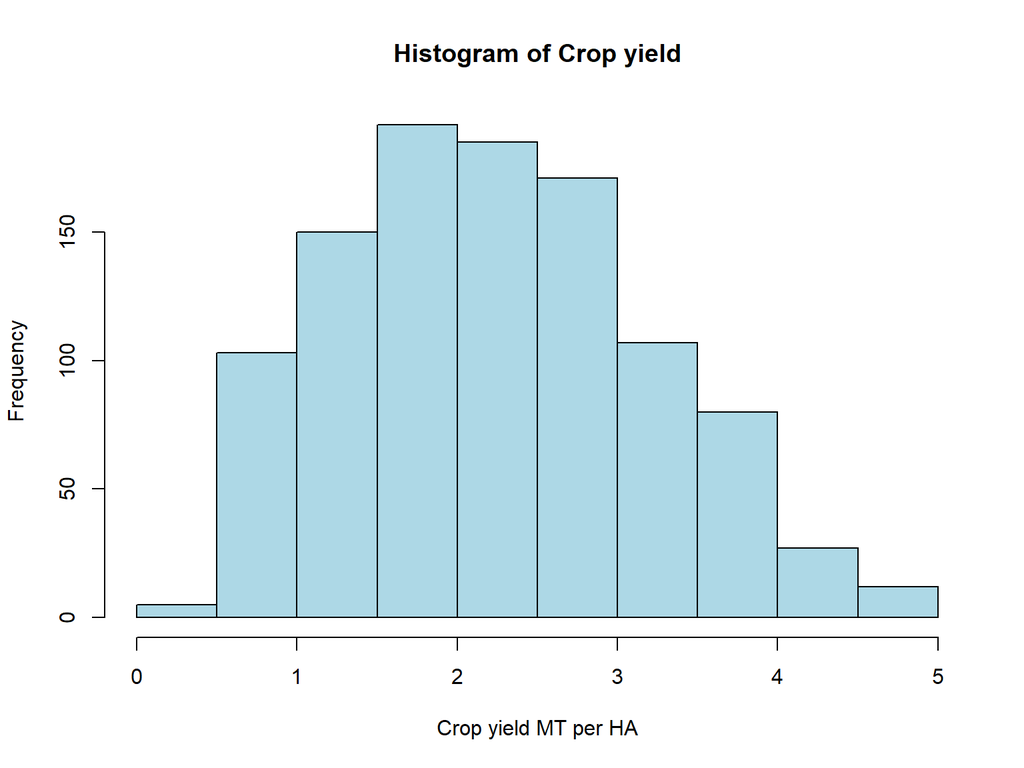

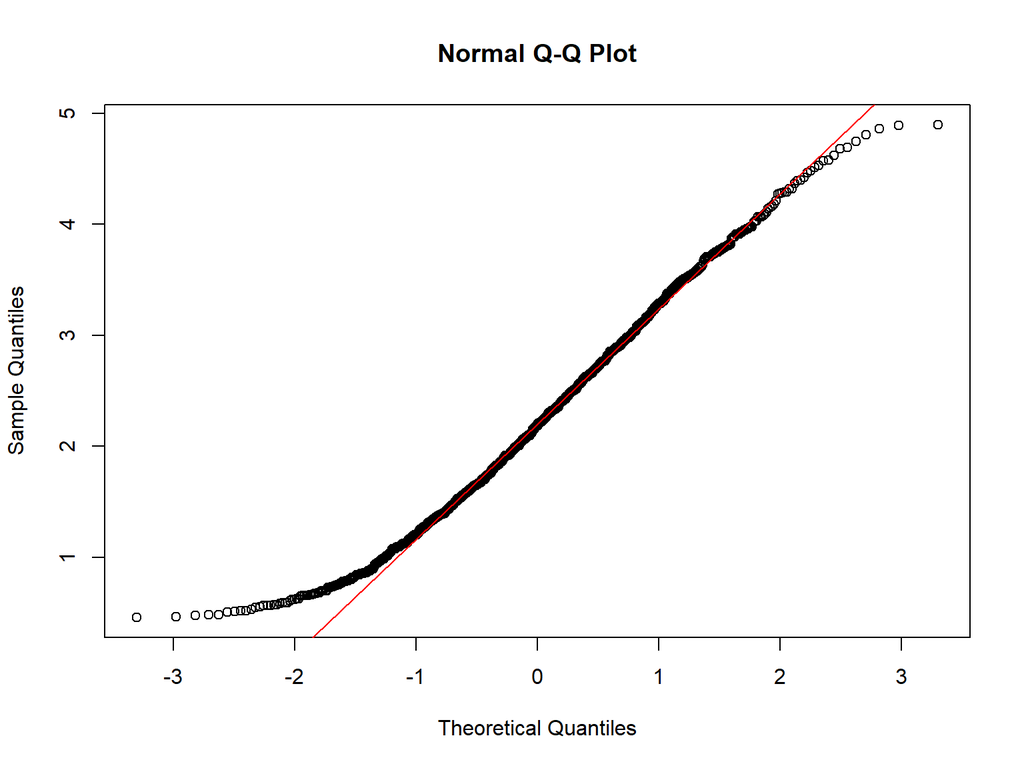

```
##
##  Shapiro-Wilk normality test
##
## data:  FM$Crop_Yield_MT_per_HA
## W = 0.98309, p-value = 1.418e-09
```

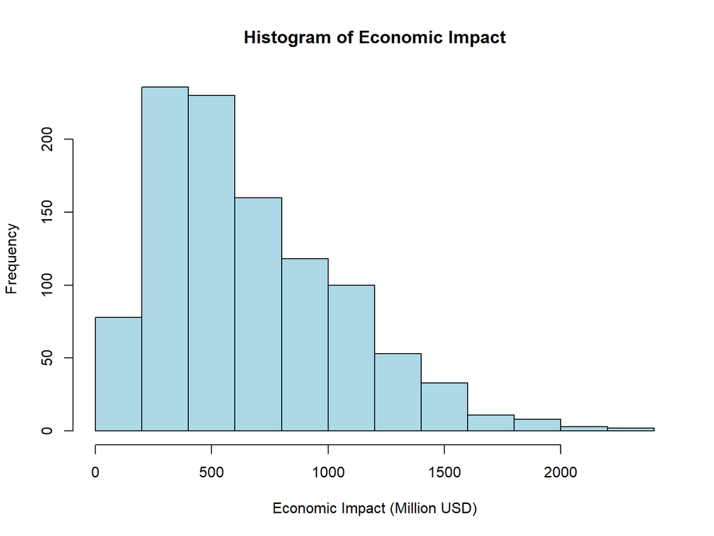

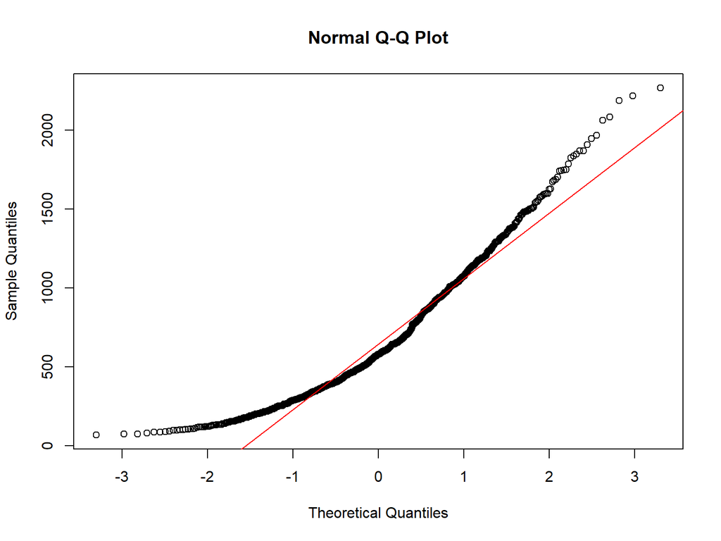

```
##
##  Shapiro-Wilk normality test
##
## data:  FM$Economic_Impact_Million_USD
## W = 0.93318, p-value < 2.2e-16
```

# Testing the significance of differences in crop yield accross the crop type

-There is no significant differences in crop yield in USA across the different crop types.

```
##  [1] "Barley"     "Coffee"     "Corn"       "Cotton"     "Fruits"
##  [6] "Rice"       "Soybeans"   "Sugarcane"  "Vegetables" "Wheat"
```

```
##               Df Sum Sq Mean Sq F value Pr(>F)
## Crop_Type      9    8.7  0.9679   1.047    0.4
## Residuals   1022  944.4  0.9240
```

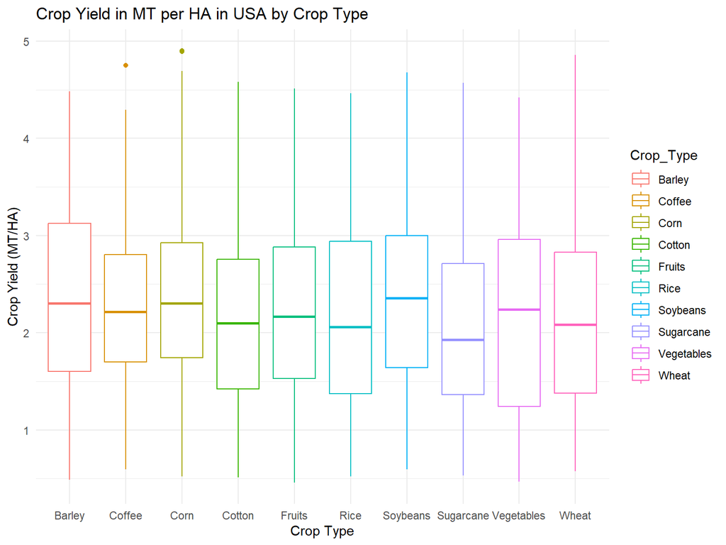

#Testing the statistical significance in economic impact due to different crop types

-There is no statistical differences in economic impact in USA due to different types of crops.

```
##               Df    Sum Sq Mean Sq F value Pr(>F)
## Crop_Type      9   1047905  116434   0.723  0.688
## Residuals   1022 164530855  160989
```

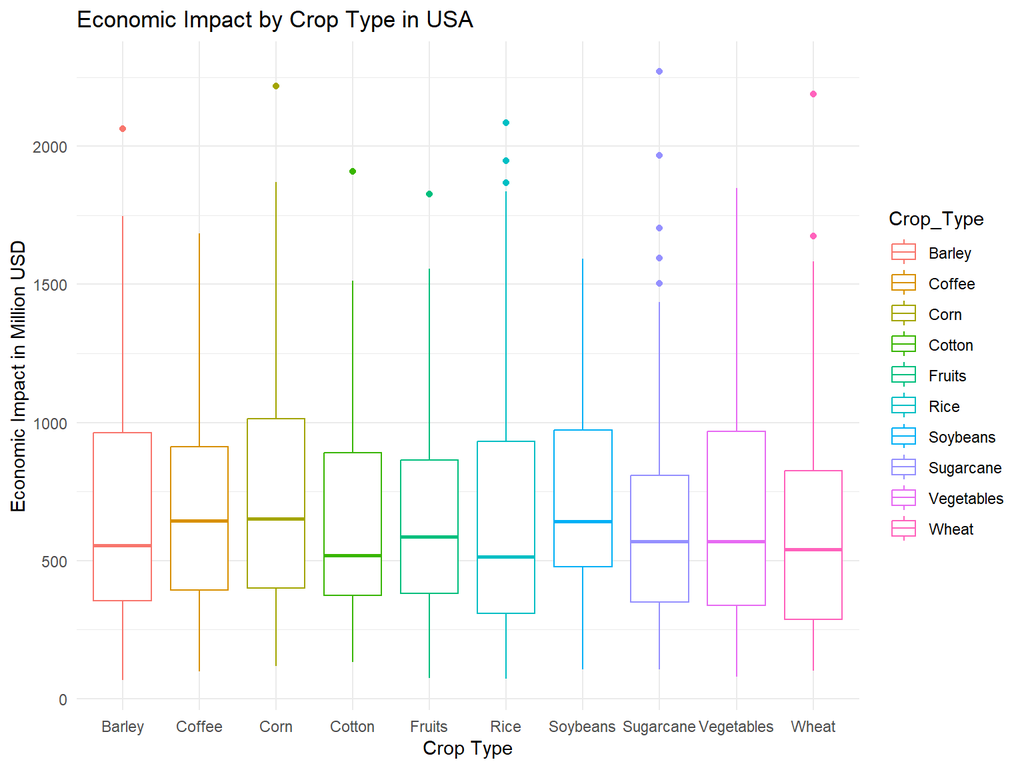

# Conclusion

Overall, Nigeria produces high crop per HA and has highest economic impact, followed by India. However, there is no statistically significant differences among the countries.

In case of USA, Coffee is the highly produced crop with highest economic impact followed by vegetables. However, there is no statistical differences in crop yield and economic impact due to different crops types and in different time. In this data multiple linear regression does not perform well, so we can not make any generalization about the impacts of different climatic and environmental variables in crop productions and economic impacts in the United State.